# Exercise 1.8

Sofie van den Brand

### 8 Monte Carlo simulation exercise

Perform a small simulation that does the following: sample 100 samples from a standard normal distribution. But first: set a seed and load some libraries:

```r
set.seed(123)
library(tidyverse)
```

Run the simulation: filling a matrix where each row presents a new sample.

```r
samples <- matrix(NA, 100, 1000)

for (i in 1:100) {
 samples[i,] <- rnorm(1000, m = 0, sd = 1)
 }
```

For each of these samples, calculate the following statistics for the mean: - absolute bias - standard error - lower bound of the 95% confidence interval - upper bound of the 95% confidence interval

```r
# Bias is sample mean - the mean which we used to create the samples
bias <- rowMeans(samples) - 0
mean_sample <- rowMeans(samples) # They are the same, but just for practice I like to keep them separate
# Variance is standard deviation squared so still 1 (which is also logical because it is a standard normal)
SE <- rep(1/sqrt(ncol(samples)), 100)
# lower bound of 95% CI
lowerCI <- mean_sample - 1.96 * SE
# upper bound of 95% CI:
upperCI <- mean_sample + 1.96 * SE

## Putting it all together in a dataframe
results <- as.data.frame(cbind(mean_sample, bias, SE, lowerCI, upperCI))
```

Create a plot that demonstrates the following:

“A replication of the procedure that generates a 95% confidence interval that is centered around the sample mean would cover the population value at least 95 out of 100 times” (Neyman, 1934)

Let’s create the plot

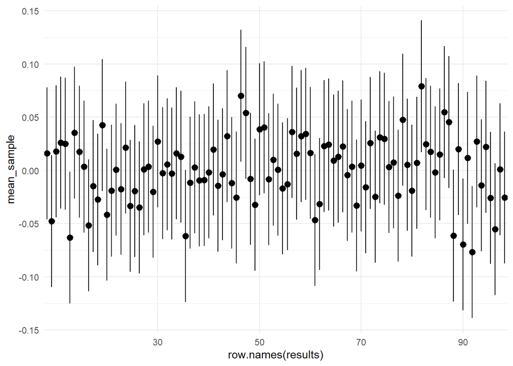

```r
ggplot(data = results,
       aes(
         x = row.names(results),
         y = mean_sample,
         ymin = lowerCI,
         ymax = upperCI
       )) +
  geom_pointrange() +
  theme_minimal() +
  scale_x_discrete(breaks = c(0, 30, 50, 70, 90))
```

Now it is still hard to see which ones do not contain 0 within the confidence interval. So let’s color them.

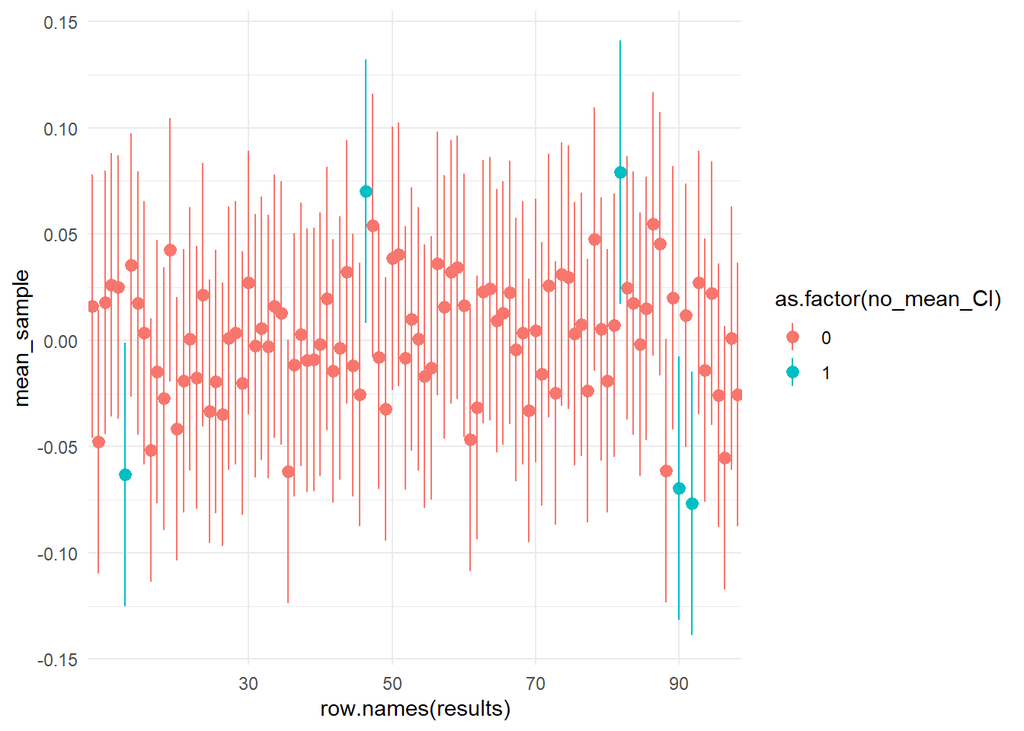

```r
results <-
  results %>% mutate(no_mean_CI = case_when(lowerCI < 0 &
                                              0 < upperCI ~ 0, TRUE ~ 1))

ggplot(data = results,
       aes(
         x = row.names(results),
         y = mean_sample,
         ymin = lowerCI,
         ymax = upperCI,
         color = as.factor(no_mean_CI)
       )) +
  geom_pointrange() + theme_minimal() +
  scale_x_discrete(breaks = c(0, 30, 50, 70, 90))
```

As can be seen, only 5 do not contain a 0 in their confidence interval, which is indeed in line with the statement above.

Present a table containing all simulated samples for which the resulting confidence interval does not contain the population value.

```r
results %>% filter(no_mean_CI == 1)
```

```
##   mean_sample        bias         SE      lowerCI      upperCI no_mean_CI
## 1 -0.06304966 -0.06304966 0.03162278 -0.125030301 -0.001069017          1
## 2  0.06998379  0.06998379 0.03162278  0.008003148  0.131964433          1
## 3  0.07905560  0.07905560 0.03162278  0.017074963  0.141036247          1
## 4 -0.06954734 -0.06954734 0.03162278 -0.131527986 -0.007566702          1
## 5 -0.07689709 -0.07689709 0.03162278 -0.138877735 -0.014916451          1
```